# UGR calculation after CIE standard

William Truong

15.09.2021

# 1 Introduction

From CIE-190 2010 Standard.

box form, cycle form and cylindrical form need to be checked.

UGR basic equation

$$R_\text{UG} = 8 \log \left[ \frac{0.25}{L_\text{b}}\sum \frac{L^2\omega}{p^2} \right]$$
Using standard luminaire arrangements (e.g. 2H x 4H), this formula can be simplified to (see CIE-190 2010)

$$R_\text{UG} = 8 \log \left[ \sum \frac{K I_{C\gamma}^2}{A} \right] - 8 \log E_\text{WID}$$

# 2 CIE 190:2010 tables

## 2.1 Luminous intensity table in cd/klm

```r
df_I <- readWorkbook(
    "CIE-190-2010_tables.xlsx",
    sheet = "Table 7",
    startRow = 2
    )
```

## 2.2 Pre-calculated parameters for luminaires in the standard array

```r
t2 <- readWorkbook("CIE-190-2010_tables.xlsx", sheet = "Table 2", startRow = 1)
kable(t2)
```

| y_R/H | x_T/H | C | gamma | K | H/D | y_R/D | x_T/D |
| --- | --- | --- | --- | --- | --- | --- | --- |
| 0.5 | 0.5 | 45.00 | 35.26 | NA | 0.8165 | 0.4082 | 0.4082 |
| 1.5 | 0.5 | 18.43 | 57.69 | 0.00412 | 0.5345 | 0.8018 | 0.2673 |
| 2.5 | 0.5 | 11.31 | 68.58 | 0.00541 | 0.3651 | 0.9129 | 0.1826 |
| 3.5 | 0.5 | 8.13 | 74.21 | 0.00473 | 0.2722 | 0.9526 | 0.1361 |
| 4.5 | 0.5 | 6.34 | 77.55 | 0.00386 | 0.2157 | 0.9705 | 0.1078 |
| 5.5 | 0.5 | 5.19 | 79.74 | 0.00308 | 0.1782 | 0.9800 | 0.0891 |
| 6.5 | 0.5 | 4.40 | 81.28 | 0.00243 | 0.1516 | 0.9855 | 0.0758 |
| 7.5 | 0.5 | 3.81 | 82.42 | 0.00197 | 0.1319 | 0.9891 | 0.0659 |
| 8.5 | 0.5 | 3.37 | 83.30 | 0.00163 | 0.1166 | 0.9915 | 0.0583 |
| 9.5 | 0.5 | 3.01 | 84.00 | 0.00137 | 0.1045 | 0.9931 | 0.0523 |
| 10.5 | 0.5 | 2.73 | 84.57 | 0.00116 | 0.0947 | 0.9944 | 0.0474 |
| 11.5 | 0.5 | 2.49 | 85.03 | 0.00100 | 0.0865 | 0.9953 | 0.0433 |
| 0.5 | 1.5 | 71.57 | 57.69 | NA | 0.5345 | 0.2673 | 0.8018 |
| 1.5 | 1.5 | 45.00 | 64.76 | 0.00155 | 0.4264 | 0.6396 | 0.6396 |
| 2.5 | 1.5 | 30.96 | 71.07 | 0.00294 | 0.3244 | 0.8111 | 0.4867 |
| 3.5 | 1.5 | 23.20 | 75.29 | 0.00329 | 0.2540 | 0.8890 | 0.3810 |
| 4.5 | 1.5 | 18.43 | 78.10 | 0.00292 | 0.2063 | 0.9283 | 0.3094 |
| 5.5 | 1.5 | 15.26 | 80.05 | 0.00249 | 0.1728 | 0.9503 | 0.2592 |
| 6.5 | 1.5 | 12.99 | 81.47 | 0.00209 | 0.1482 | 0.9636 | 0.2224 |
| 7.5 | 1.5 | 11.31 | 82.55 | 0.00177 | 0.1296 | 0.9723 | 0.1945 |
| 8.5 | 1.5 | 10.01 | 83.39 | 0.00150 | 0.1151 | 0.9782 | 0.1726 |
| 9.5 | 1.5 | 8.97 | 84.06 | 0.00129 | 0.1034 | 0.9825 | 0.1551 |
| 10.5 | 1.5 | 8.13 | 84.61 | 0.00111 | 0.0939 | 0.9856 | 0.1408 |
| 11.5 | 1.5 | 7.43 | 85.07 | 0.00097 | 0.0859 | 0.9879 | 0.1289 |
| 0.5 | 2.5 | 78.69 | 68.58 | NA | 0.3651 | 0.1826 | 0.9129 |
| 1.5 | 2.5 | 59.04 | 71.07 | 0.00053 | 0.3244 | 0.4867 | 0.8111 |
| 2.5 | 2.5 | 45.00 | 74.21 | 0.00119 | 0.2722 | 0.6804 | 0.6804 |
| 3.5 | 2.5 | 35.54 | 76.91 | 0.00166 | 0.2265 | 0.7926 | 0.5661 |
| 4.5 | 2.5 | 29.05 | 79.01 | 0.00183 | 0.1907 | 0.8581 | 0.4767 |
| 5.5 | 2.5 | 24.44 | 80.60 | 0.00176 | 0.1633 | 0.8981 | 0.4082 |
| 6.5 | 2.5 | 21.04 | 81.83 | 0.00159 | 0.1421 | 0.9239 | 0.3553 |
| 7.5 | 2.5 | 18.43 | 82.79 | 0.00140 | 0.1255 | 0.9412 | 0.3137 |
| 8.5 | 2.5 | 16.39 | 83.56 | 0.00124 | 0.1122 | 0.9533 | 0.2804 |
| 9.5 | 2.5 | 14.74 | 84.19 | 0.00109 | 0.1013 | 0.9621 | 0.2532 |
| 10.5 | 2.5 | 13.39 | 84.71 | 0.00096 | 0.0923 | 0.9687 | 0.2306 |
| 11.5 | 2.5 | 12.26 | 85.14 | 0.00084 | 0.0847 | 0.9737 | 0.2117 |
| 0.5 | 3.5 | 81.87 | 74.21 | NA | 0.2722 | 0.1361 | 0.9526 |
| 1.5 | 3.5 | 66.80 | 75.29 | 0.00024 | 0.2540 | 0.3810 | 0.8890 |
| 2.5 | 3.5 | 54.46 | 76.91 | 0.00053 | 0.2265 | 0.5661 | 0.7926 |
| 3.5 | 3.5 | 45.00 | 78.58 | 0.00083 | 0.1980 | 0.6931 | 0.6931 |
| 4.5 | 3.5 | 37.87 | 80.05 | 0.00105 | 0.1728 | 0.7775 | 0.6047 |
| 5.5 | 3.5 | 32.47 | 81.28 | 0.00115 | 0.1516 | 0.8339 | 0.5307 |
| 6.5 | 3.5 | 28.30 | 82.29 | 0.00113 | 0.1342 | 0.8725 | 0.4698 |
| 7.5 | 3.5 | 25.02 | 83.11 | 0.00106 | 0.1200 | 0.8996 | 0.4198 |
| 8.5 | 3.5 | 22.38 | 83.79 | 0.00099 | 0.1081 | 0.9193 | 0.3785 |
| 9.5 | 3.5 | 20.22 | 84.36 | 0.00090 | 0.0983 | 0.9338 | 0.3440 |
| 10.5 | 3.5 | 18.43 | 84.84 | 0.00081 | 0.0900 | 0.9448 | 0.3149 |
| 11.5 | 3.5 | 16.93 | 85.24 | 0.00073 | 0.0829 | 0.9534 | 0.2902 |
| 0.5 | 4.5 | 83.66 | 77.55 | NA | 0.2157 | 0.1078 | 0.9705 |
| 1.5 | 4.5 | 71.57 | 78.10 | 0.00015 | 0.2063 | 0.3094 | 0.9283 |
| 2.5 | 4.5 | 60.95 | 79.01 | 0.00027 | 0.1907 | 0.4767 | 0.8581 |
| 3.5 | 4.5 | 52.13 | 80.05 | 0.00045 | 0.1728 | 0.6047 | 0.7775 |
| 4.5 | 4.5 | 45.00 | 81.07 | 0.00059 | 0.1552 | 0.6985 | 0.6985 |
| 5.5 | 4.5 | 39.29 | 81.99 | 0.00072 | 0.1393 | 0.7664 | 0.6271 |
| 6.5 | 4.5 | 34.70 | 82.79 | 0.00077 | 0.1255 | 0.8157 | 0.5647 |
| 7.5 | 4.5 | 30.96 | 83.48 | 0.00078 | 0.1136 | 0.8519 | 0.5112 |
| 8.5 | 4.5 | NA | NA | NA | NA | NA | NA |
| 9.5 | 4.5 | NA | NA | NA | NA | NA | NA |
| 10.5 | 4.5 | NA | NA | NA | NA | NA | NA |
| 11.5 | 4.5 | NA | NA | NA | NA | NA | NA |
| 0.5 | 5.5 | 84.81 | 79.74 | NA | 0.1782 | 0.0891 | 0.9800 |
| 1.5 | 5.5 | 74.74 | 80.05 | NA | 0.1728 | 0.2592 | 0.9503 |
| 2.5 | 5.5 | 65.56 | 80.60 | 0.00017 | 0.1633 | 0.4082 | 0.8981 |
| 3.5 | 5.5 | 57.53 | 81.28 | 0.00026 | 0.1516 | 0.5307 | 0.8339 |
| 4.5 | 5.5 | 50.71 | 81.99 | 0.00036 | 0.1393 | 0.6271 | 0.7664 |
| 5.5 | 5.5 | 45.00 | 82.67 | 0.00044 | 0.1275 | 0.7013 | 0.7013 |
| 6.5 | 5.5 | 40.24 | 83.30 | 0.00052 | 0.1166 | 0.7582 | 0.6415 |
| 7.5 | 5.5 | 36.25 | 83.86 | 0.00056 | 0.1069 | 0.8018 | 0.5880 |
| 8.5 | 5.5 | NA | NA | NA | NA | NA | NA |
| 9.5 | 5.5 | NA | NA | NA | NA | NA | NA |
| 10.5 | 5.5 | NA | NA | NA | NA | NA | NA |
| 11.5 | 5.5 | NA | NA | NA | NA | NA | NA |

## 2.3 Data for calculation of indirect illuminance on walls for luminaires in the standard array

```r
t3 <- readWorkbook("CIE-190-2010_tables.xlsx", sheet = "Table 3", startRow = 1)
kable(t3)
```

| X_Dim | Y_Dim | Room_Index | No_luminaires | Wall_Area | B |
| --- | --- | --- | --- | --- | --- |
| 2H | 2H | 1.00 | 4 | 32 | 125.00 |
| 2H | 3H | 1.20 | 6 | 40 | 150.00 |
| 2H | 4H | 1.33 | 8 | 48 | 166.67 |
| 2H | 6H | 1.50 | 12 | 64 | 187.50 |
| 2H | 8H | 1.60 | 16 | 80 | 200.00 |
| 2H | 12H | 1.71 | 24 | 112 | 214.29 |
| 4H | 2H | 1.33 | 8 | 48 | 166.67 |
| 4H | 3H | 1.71 | 12 | 56 | 214.29 |
| 4H | 4H | 2.00 | 16 | 64 | 250.00 |
| 4H | 6H | 2.40 | 24 | 80 | 300.00 |
| 4H | 8H | 2.67 | 32 | 96 | 333.33 |
| 4H | 12H | 3.00 | 48 | 128 | 375.00 |
| 8H | 4H | 2.67 | 32 | 96 | 333.33 |
| 8H | 6H | 3.43 | 48 | 112 | 428.57 |
| 8H | 8H | 4.00 | 64 | 128 | 500.00 |
| 8H | 12H | 4.80 | 96 | 160 | 600.00 |
| 12H | 4H | 3.00 | 48 | 128 | 375.00 |
| 12H | 6H | 4.00 | 72 | 144 | 500.00 |
| 12H | 8H | 4.80 | 96 | 160 | 600.00 |

## 2.4 Geometric factor values for luminaires in the standard array

```r
t4 <- readWorkbook("CIE-190-2010_tables.xlsx", sheet = "Table 4", startRow = 1)
kable(t4)
```

| X_Dim | Y_Dim | Room_Index | F_GL1 | F_GL2 | F_GL3 | F_GL4 |
| --- | --- | --- | --- | --- | --- | --- |
| 2H | 2H | 1.00 | 0.690 | 0.109 | 0.085 | -0.016 |
| 2H | 3H | 1.20 | 0.578 | 0.200 | 0.127 | -0.018 |
| 2H | 4H | 1.33 | 0.528 | 0.218 | 0.170 | -0.017 |
| 2H | 6H | 1.50 | 0.485 | 0.215 | 0.222 | -0.012 |
| 2H | 8H | 1.60 | 0.466 | 0.207 | 0.249 | -0.006 |
| 2H | 12H | 1.71 | 0.448 | 0.198 | 0.272 | 0.005 |
| 4H | 2H | 1.33 | 0.528 | 0.218 | 0.170 | -0.017 |
| 4H | 3H | 1.71 | 0.394 | 0.275 | 0.268 | -0.020 |
| 4H | 4H | 2.00 | 0.338 | 0.257 | 0.351 | -0.018 |
| 4H | 6H | 2.40 | 0.296 | 0.203 | 0.449 | -0.006 |
| 4H | 8H | 2.67 | 0.280 | 0.165 | 0.499 | 0.006 |
| 4H | 12H | 3.00 | 0.264 | 0.125 | 0.541 | 0.027 |
| 8H | 4H | 2.67 | 0.280 | 0.165 | 0.499 | 0.006 |
| 8H | 6H | 3.43 | 0.248 | 0.058 | 0.628 | 0.032 |
| 8H | 8H | 4.00 | 0.239 | -0.012 | 0.690 | 0.058 |
| 8H | 12H | 4.80 | 0.232 | -0.084 | 0.740 | 0.098 |
| 12H | 4H | 3.00 | 0.264 | 0.125 | 0.541 | 0.027 |
| 12H | 6H | 4.00 | 0.238 | -0.003 | 0.677 | 0.063 |
| 12H | 8H | 4.80 | 0.232 | -0.084 | 0.740 | 0.098 |

## 2.5 Transfer factor values

```r
t5 <- readWorkbook(
    "CIE-190-2010_tables.xlsx",
    sheet = "Table 5_long",
    startRow = 1
    )
kable(t5)
```

| Reflectance_C/W/R | X_Dim | Y_Dim | k | F_T,FW | F_T,WW-1 | F_T,CW |
| --- | --- | --- | --- | --- | --- | --- |
| 70/50/20 | 2H | 2H | 1.00 | 0.220 | 0.422 | 0.646 |
| 70/50/20 | 2H | 3H | 1.20 | 0.199 | 0.376 | 0.571 |
| 70/50/20 | 2H | 4H | 1.33 | 0.187 | 0.351 | 0.531 |
| 70/50/20 | 2H | 6H | 1.50 | 0.174 | 0.322 | 0.488 |
| 70/50/20 | 2H | 8H | 1.60 | 0.167 | 0.307 | 0.466 |
| 70/50/20 | 2H | 12H | 1.71 | 0.160 | 0.290 | 0.443 |
| 70/50/20 | 4H | 2H | 1.33 | 0.187 | 0.351 | 0.531 |
| 70/50/20 | 4H | 3H | 1.71 | 0.158 | 0.295 | 0.439 |
| 70/50/20 | 4H | 4H | 2.00 | 0.142 | 0.265 | 0.389 |
| 70/50/20 | 4H | 6H | 2.40 | 0.124 | 0.230 | 0.335 |
| 70/50/20 | 4H | 8H | 2.67 | 0.115 | 0.211 | 0.307 |
| 70/50/20 | 4H | 12H | 3.00 | 0.105 | 0.190 | 0.279 |
| 70/50/20 | 8H | 4H | 2.67 | 0.115 | 0.211 | 0.307 |
| 70/50/20 | 8H | 6H | 3.43 | 0.094 | 0.175 | 0.247 |
| 70/50/20 | 8H | 8H | 4.00 | 0.083 | 0.155 | 0.215 |
| 70/50/20 | 8H | 12H | 4.80 | 0.071 | 0.133 | 0.183 |
| 70/50/20 | 12H | 4H | 3.00 | 0.105 | 0.190 | 0.279 |
| 70/50/20 | 12H | 6H | 4.00 | 0.083 | 0.153 | 0.216 |
| 70/50/20 | 12H | 8H | 4.80 | 0.071 | 0.133 | 0.183 |
| 70/30/20 | 2H | 2H | 1.00 | 0.166 | 0.217 | 0.553 |
| 70/30/20 | 2H | 3H | 1.20 | 0.173 | 0.196 | 0.497 |
| 70/30/20 | 2H | 4H | 1.33 | 0.164 | 0.184 | 0.465 |
| 70/30/20 | 2H | 6H | 1.50 | 0.154 | 0.171 | 0.432 |
| 70/30/20 | 2H | 8H | 1.60 | 0.149 | 0.164 | 0.415 |
| 70/30/20 | 2H | 12H | 1.71 | 0.143 | 0.156 | 0.397 |
| 70/30/20 | 4H | 2H | 1.33 | 0.164 | 0.184 | 0.465 |
| 70/30/20 | 4H | 3H | 1.71 | 0.142 | 0.159 | 0.393 |
| 70/30/20 | 4H | 4H | 2.00 | 0.129 | 0.144 | 0.351 |
| 70/30/20 | 4H | 6H | 2.40 | 0.114 | 0.127 | 0.307 |
| 70/30/20 | 4H | 8H | 2.67 | 0.106 | 0.117 | 0.283 |

[output cut: 65 more lines]

# 3 Working Example

## 3.1 Luminaire data and pre-definitions

```r
X <- "2H"
Y <- "4H"
reflectance <- "70/50/20"
# luminous areas in m²
A_B <- 0.316
A_S <- 0
A_E <- 0

flux_0 <- 1000
```

The standard array area are defined by the X and Y Dimension (2H x 4H) including the position of the luminaires (see following figure). Area A: 2H x 4H, Area B: 8H x 6H

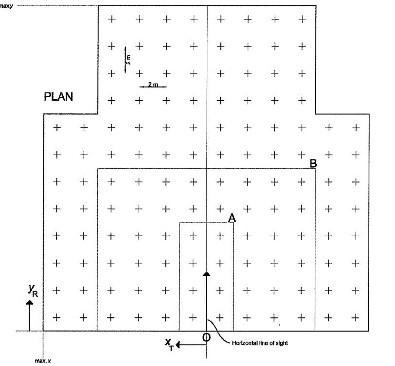

## 3.2 Calculation of $E_\text{WID}$ Value

1. Calculate the average intensity from luminous intensity table fro every 10° $\gamma$ angle
2. Multiply with pre-defined zone factor to get Zonal Flux (ExF)

```r
zone_factor = c(0.095, 0.283, 0.463, 0.628, 0.774, 0.897, 0.993, 1.058, 1.091)
df_90 <- df_I %>%
    filter(gamma %in% seq(5, 85, 10)) %>%
    mutate(
        AverageIntensity = rowMeans(across(C0:C345)),
        ZoneFactor = zone_factor,
        ZonalFlux = round(AverageIntensity * ZoneFactor, 2),
        # Wrong average intensities check CIE standard
        ZonalFlux = c(25.10,  72.55, 106.69, 120.47, 116.03,
                                    95.71,  66.66,  37.58, 11.95)
        )
flux_total_90 <- sum(df_90$ZonalFlux)
df_180 <- df_I %>%
    filter(gamma %in% seq(95, 175, 10)) %>%
    mutate(
        AverageIntensity = rowMeans(across(C0:C345)),
        ZoneFactor = rev(zone_factor),
        ZonalFlux = (AverageIntensity * ZoneFactor) %>% round(2)
        )
flux_total <- flux_total_90 + sum(df_180$ZonalFlux)
```

$$R_\text{LO} = \frac{\text{Total flux in arbitrary units (M)}}{\text{Total bare lamp flux in arbitrary units}}$$
$$F_\text{S} = \frac{R_\text{LO} \cdot 1000}{\text{Total flux in arbitrary units (M)}}$$
$$R_\text{DLO} = \frac{\text{Total flux 0° to 90° in arbitrary units (L)} \cdot F_\text{S}}{1000}$$
$$R_\text{ULO} = R_\text{LO} - R_\text{DLO}$$

```r
R_LO  <- (flux_total_90 / flux_0) %>% round(2)
F_S   <- (R_LO * 1000 / flux_total) %>% round(3)
R_DLO <- (flux_total_90 * F_S / 1000) %>% round(2)
R_ULO <- R_LO - R_DLO
```

3. Calculating the cumulative CIE zonal flux using scale factor $F_\text{S}$

```r
df_90 <- df_90 %>%
    mutate(
        ZonalFlux_FxSF = (ZonalFlux * F_S) %>% round(2),
        # rounding problems in CIE standard
        ZonalFlux_FxSF = c(25.00, 72.26, 106.26, 119.98, 115.57,
                                             95.32, 66.39,  37.43, 11.91)
        )

zonal_flux_0_40 <- df_90 %>%
    filter(0 < gamma & gamma < 40) %>%
    summarise(across(ZonalFlux_FxSF, sum)) %>%
    pull()
zonal_flux_0_60 <- df_90 %>%
    filter(0 < gamma & gamma < 60) %>%
    summarise(across(ZonalFlux_FxSF, sum)) %>%
    pull()
zonal_flux_0_70 <- df_90 %>%
    filter(0 < gamma & gamma < 70) %>%
    summarise(across(ZonalFlux_FxSF, sum)) %>%
    pull()
zonal_flux_0_90 <- df_90 %>%
    filter(0 < gamma & gamma < 90) %>%
    summarise(across(ZonalFlux_FxSF, sum)) %>%
    pull()
zonal_flux_40_50 <- df_90 %>%
    filter(40 < gamma & gamma < 50) %>%
    summarise(across(ZonalFlux_FxSF, sum)) %>%
    pull()
zonal_flux_70_80 <- df_90 %>%
    filter(70 < gamma & gamma < 80) %>%
    summarise(across(ZonalFlux_FxSF, sum)) %>%
    pull()

flux_zL1 <- (zonal_flux_0_40 + 0.130 * zonal_flux_40_50) %>% round(2)
flux_zL2 <-  zonal_flux_0_60 %>% round(2)
flux_zL3 <- (zonal_flux_0_70 + 0.547 * zonal_flux_70_80) %>% round(2)
flux_zL4 <-  zonal_flux_0_90 %>% round(2)
```

4. Calculate the distributions factors using X and Y dimensions

```r
F_GL <- filter(t4, X_Dim == X & Y_Dim == Y)

F_GL1 <- F_GL$F_GL1
F_GL2 <- F_GL$F_GL2
F_GL3 <- F_GL$F_GL3
F_GL4 <- F_GL$F_GL4

flux_zL <- (flux_zL1 * F_GL1 + flux_zL2 * F_GL2 +
                        flux_zL3 * F_GL3 + flux_zL4 * F_GL4) %>% round(2)

F_DF <- (flux_zL / flux_0) %>% round(2)
F_DW <- R_DLO - F_DF
F_DC <- R_ULO
```

5. Calculate the indirect utilisation factor for walls using reflectance, transfer factor values, X and Y dimensions

```r
F_T <- filter(t5, `Reflectance_C/W/R` == reflectance & X_Dim == X & Y_Dim == Y)

`F_T,FW` <- F_T$`F_T,FW`
`F_T,WW-1` <- F_T$`F_T,WW-1`
`F_T,CW` <- F_T$`F_T,CW`

F_UWID <- (F_DF * `F_T,FW` + F_DW * `F_T,WW-1` + F_DC * `F_T,CW`) %>% round(4)
```

6. Calculate $E_\text{WID}$

```r
B <- filter(t3, X_Dim == X & Y_Dim == Y) %>% pull(B)

E_WID <- (F_UWID * B) %>% round(2)
```

## 3.3 Calculation of uncorrected UGR Value

1. Linear interpolation of luminous intensity based on light distribution
2. Calculate projected areas for luminaires viewed crosswise and endwise

```r
gamma_x <- df_I$gamma
df <- select(df_I, -(gamma)) %>%
    mutate(C360 = C0)
C_x <- colnames(df) %>% sub("C", "", .) %>% as.numeric()
I_x <- data.matrix(df) %>% t()

# for linear intepolating the luminous intensity data
y_R_H <- stringr::str_sub(Y, 1, nchar(Y) - 1) %>% as.numeric() - 0.5
x_T_H <- stringr::str_sub(X, 1, nchar(X) - 1) %>% as.numeric() / 2 - 0.5

df_sub <- filter(t2, `x_T/H` <= x_T_H)

df_cross <- df_end <- data.frame()

for (i_x in unique(df_sub$`x_T/H`)) {
    df_sub2 <- df_sub %>%
        filter(`x_T/H` == i_x & `y_R/H` <= y_R_H) %>%
        drop_na()
    df_cross <- df_sub2 %>%
        mutate(C = 360 - C) %>%
        bind_rows(df_sub2, .) %>%
        mutate(
            I_Cgamma = pracma::interp2(gamma_x, C_x, I_x, gamma, C),
            #I_Cgamma = c(83.03, 47.12, 29.70, 83.03, 47.12, 29.70), # correction
            A = (A_B * `H/D` + A_S * `y_R/D` + A_E * `x_T/D`) %>% round(3)
            ) %>%
        bind_rows(df_cross, .)

    df_sub3 <- df_sub2 %>% mutate(C = 90 + C)
    df_end <- df_sub2 %>%
        mutate(C = 90 - C) %>%
        bind_rows(df_sub3, .) %>%
        mutate(
            I_Cgamma = pracma::interp2(gamma_x, C_x, I_x, gamma, C),
            #I_Cgamma = c(106.55, 65.57, 46.22, 106.55, 65.57, 46.22), # correction
            A = (A_B * `H/D` + A_S * `x_T/D` + A_E * `y_R/D`) %>% round(3)
            ) %>%
        bind_rows(df_end, .)
}
```

3. Calculate uncorrected UGR viewed crosswise

```r
K <- df_cross$K
I_Cgamma <- df_cross$I_Cgamma
A <- df_cross$A

UGR_cross <- (8 * log10(sum(K * I_Cgamma^2 / A)) - 8 * log10(E_WID)) %>%
    round(1)
print(UGR_cross)
```

```
## [1] 11
```

4. Calculate uncorrected UGR viewed endwise

```r
K <- df_end$K
I_Cgamma <- df_end$I_Cgamma
A <- df_end$A

UGR_end <- (8 * log10(sum(K * I_Cgamma^2 / A)) - 8 * log10(E_WID)) %>%
    round(1)
print(UGR_end)
```

```
## [1] 13.1
```

## 3.4 Calculation of corrected UGR Value

$$R_\text{UG}(\phi) = R_\text{UG}(\phi_0) + 8 \log \left( \frac{\phi}{\phi_0} \right)$$

# 4 Calculation of UGR table

```r
UGR_table <- t5 %>%
    select(`Reflectance_C/W/R`:Y_Dim) %>%
    mutate(UGR_cross = NA, UGR_end = NA)

for (i in seq(nrow(UGR_table))) {
    # pre-definitions
    X <- UGR_table$X_Dim[i]
    Y <- UGR_table$Y_Dim[i]
    reflectance <- UGR_table$`Reflectance_C/W/R`[i]

    # cumulative CIE zonal flux
    df_90 <- df_90 %>%
    mutate(ZonalFlux_FxSF = (ZonalFlux * F_S) %>% round(2))

    zonal_flux_0_40 <- df_90 %>%
        filter(0 < gamma & gamma < 40) %>%
        summarise(across(ZonalFlux_FxSF, sum)) %>%
        pull()
    zonal_flux_0_60 <- df_90 %>%
        filter(0 < gamma & gamma < 60) %>%
        summarise(across(ZonalFlux_FxSF, sum)) %>%
        pull()
    zonal_flux_0_70 <- df_90 %>%
        filter(0 < gamma & gamma < 70) %>%
        summarise(across(ZonalFlux_FxSF, sum)) %>%
        pull()
    zonal_flux_0_90 <- df_90 %>%
        filter(0 < gamma & gamma < 90) %>%
        summarise(across(ZonalFlux_FxSF, sum)) %>%
        pull()
    zonal_flux_40_50 <- df_90 %>%
        filter(40 < gamma & gamma < 50) %>%
        summarise(across(ZonalFlux_FxSF, sum)) %>%
        pull()
    zonal_flux_70_80 <- df_90 %>%
        filter(70 < gamma & gamma < 80) %>%
        summarise(across(ZonalFlux_FxSF, sum)) %>%
        pull()

    # distributions factors
    flux_zL1 <- (zonal_flux_0_40 + 0.130 * zonal_flux_40_50) %>% round(2)
    flux_zL2 <-  zonal_flux_0_60 %>% round(2)
    flux_zL3 <- (zonal_flux_0_70 + 0.547 * zonal_flux_70_80) %>% round(2)
    flux_zL4 <-  zonal_flux_0_90 %>% round(2)

    F_GL <- filter(t4, X_Dim == X & Y_Dim == Y)

    F_GL1 <- F_GL$F_GL1
    F_GL2 <- F_GL$F_GL2
    F_GL3 <- F_GL$F_GL3
    F_GL4 <- F_GL$F_GL4

    flux_zL <- (flux_zL1 * F_GL1 + flux_zL2 * F_GL2 +
                            flux_zL3 * F_GL3 + flux_zL4 * F_GL4) %>% round(2)

    F_DF <- (flux_zL / flux_0) %>% round(2)
    F_DW <- R_DLO - F_DF
    F_DC <- R_ULO

    # indirect utilisation factor for walls
    F_T <- t5 %>%
        filter(`Reflectance_C/W/R` == reflectance & X_Dim == X & Y_Dim == Y)

    `F_T,FW` <- F_T$`F_T,FW`
    `F_T,WW-1` <- F_T$`F_T,WW-1`
    `F_T,CW` <- F_T$`F_T,CW`

    F_UWID <- (F_DF * `F_T,FW` + F_DW * `F_T,WW-1` + F_DC * `F_T,CW`) %>% round(4)

    # E_WID
    B <- filter(t3, X_Dim == X & Y_Dim == Y) %>% pull(B)
    E_WID <- (F_UWID * B) %>% round(2)

    # calculate UGR values
    gamma_x <- df_I$gamma
    df <- select(df_I, -(gamma)) %>%
        mutate(C360 = C0)
    C_x <- colnames(df) %>% sub("C", "", .) %>% as.numeric()
    I_x <- data.matrix(df) %>% t()

    # for linear intepolating the luminous intensity data
    y_R_H <- stringr::str_sub(Y, 1, nchar(Y) - 1) %>% as.numeric() - 0.5
    x_T_H <- stringr::str_sub(X, 1, nchar(X) - 1) %>% as.numeric() / 2 - 0.5

    df_sub <- filter(t2, `x_T/H` <= x_T_H)

    df_cross <- df_end <- data.frame()

    for (i_x in unique(df_sub$`x_T/H`)) {
        df_sub2 <- df_sub %>%
            filter(`x_T/H` == i_x & `y_R/H` <= y_R_H) %>%
            drop_na()
        df_cross <- df_sub2 %>%
            mutate(C = 360 - C) %>%
            bind_rows(df_sub2, .) %>%
            mutate(
                I_Cgamma = pracma::interp2(gamma_x, C_x, I_x, gamma, C),
                A = (A_B * `H/D` + A_S * `y_R/D` + A_E * `x_T/D`) %>% round(3)
                ) %>%
            bind_rows(df_cross, .)

        df_sub3 <- df_sub2 %>% mutate(C = 90 + C)
        df_end <- df_sub2 %>%
            mutate(C = 90 - C) %>%
            bind_rows(df_sub3, .) %>%
            mutate(
                I_Cgamma = pracma::interp2(gamma_x, C_x, I_x, gamma, C),
                A = (A_B * `H/D` + A_S * `x_T/D` + A_E * `y_R/D`) %>% round(3)
                ) %>%
            bind_rows(df_end, .)
    }

    # UGR viewed crosswise
    K <- df_cross$K
    I_Cgamma <- df_cross$I_Cgamma
    A <- df_cross$A

    UGR_cross <- (8 * log10(sum(K * I_Cgamma^2 / A)) - 8 * log10(E_WID)) %>%
        round(1)
    UGR_table$UGR_cross[i] <- UGR_cross

    # UGR viewed endwise
    K <- df_end$K
    I_Cgamma <- df_end$I_Cgamma
    A <- df_end$A

    UGR_end <- (8 * log10(sum(K * I_Cgamma^2 / A)) - 8 * log10(E_WID)) %>%
        round(1)
    UGR_table$UGR_end[i] <- UGR_end
}
```

## 4.1 printing UGR table

```r
library(kableExtra)
dt <- UGR_table %>%
    pivot_wider(names_from = `Reflectance_C/W/R`, values_from = c(UGR_cross, UGR_end))

reflectance_names <- unique(UGR_table$`Reflectance_C/W/R`)

kbl(
    dt,
    align = c("r"),
    col.names = c("X", "Y", reflectance_names, reflectance_names)
    ) %>%
    kable_classic_2() %>%
    add_header_above(c(
        "Room Dimensions" = 2,
        "Reflectances (Ceiling/Wall/Reference plane)" = 5,
        "Reflectances (Ceiling/Wall/Reference plane)" = 5
        )) %>%
    add_header_above(c(
        " " = 2,
        "Viewed crosswise" = 5,
        "Viewed endwise" = 5
        )) %>%
    row_spec(c(6, 12, 16), extra_css = "border-bottom: 1px solid")
```

| Room Dimensions X | Room Dimensions Y | Viewed crosswise Reflectances (Ceiling/Wall/Reference plane) 70/50/20 | Viewed crosswise Reflectances (Ceiling/Wall/Reference plane) 70/30/20 | Viewed crosswise Reflectances (Ceiling/Wall/Reference plane) 50/50/20 | Viewed crosswise Reflectances (Ceiling/Wall/Reference plane) 50/30/20 | Viewed crosswise Reflectances (Ceiling/Wall/Reference plane) 30/30/20 | Viewed endwise Reflectances (Ceiling/Wall/Reference plane) 70/50/20 | Viewed endwise Reflectances (Ceiling/Wall/Reference plane) 70/30/20 | Viewed endwise Reflectances (Ceiling/Wall/Reference plane) 50/50/20 | Viewed endwise Reflectances (Ceiling/Wall/Reference plane) 50/30/20 | Viewed endwise Reflectances (Ceiling/Wall/Reference plane) 30/30/20 |
| --- | --- | --- | --- | --- | --- | --- | --- | --- | --- | --- | --- |
| 2H | 2H | 9.0 | 10.7 | 9.3 | 10.9 | 11.2 | 10.6 | 12.4 | 11.0 | 12.5 | 12.8 |
| 2H | 3H | 10.5 | 11.9 | 10.9 | 12.2 | 12.6 | 12.4 | 13.9 | 12.8 | 14.2 | 14.5 |
| 2H | 4H | 11.0 | 12.4 | 11.4 | 12.7 | 13.1 | 13.1 | 14.5 | 13.5 | 14.8 | 15.2 |
| 2H | 6H | 11.6 | 12.8 | 12.0 | 13.2 | 13.5 | 13.6 | 14.8 | 14.0 | 15.2 | 15.6 |
| 2H | 8H | 11.8 | 13.0 | 12.2 | 13.4 | 13.8 | 13.8 | 14.9 | 14.2 | 15.3 | 15.7 |
| 2H | 12H | 12.1 | 13.2 | 12.5 | 13.6 | 14.0 | 13.8 | 15.0 | 14.3 | 15.3 | 15.8 |
| 4H | 2H | 9.7 | 11.0 | 10.1 | 11.3 | 11.7 | 11.0 | 12.4 | 11.4 | 12.7 | 13.1 |
| 4H | 3H | 11.4 | 12.5 | 11.8 | 12.9 | 13.3 | 13.0 | 14.2 | 13.4 | 14.5 | 14.9 |
| 4H | 4H | 12.1 | 13.1 | 12.5 | 13.5 | 13.9 | 13.9 | 14.9 | 14.3 | 15.3 | 15.7 |
| 4H | 6H | 12.7 | 13.6 | 13.2 | 14.0 | 14.5 | 14.5 | 15.4 | 14.9 | 15.8 | 16.3 |
| 4H | 8H | 13.1 | 13.9 | 13.5 | 14.3 | 14.8 | 14.7 | 15.5 | 15.2 | 16.0 | 16.4 |
| 4H | 12H | 13.4 | 14.1 | 13.9 | 14.6 | 15.1 | 14.8 | 15.5 | 15.3 | 16.0 | 16.5 |
| 8H | 4H | 12.4 | 13.2 | 12.9 | 13.7 | 14.1 | 14.0 | 14.8 | 14.5 | 15.3 | 15.8 |
| 8H | 6H | 13.2 | 13.9 | 13.7 | 14.4 | 14.9 | 14.8 | 15.4 | 15.3 | 15.9 | 16.4 |
| 8H | 8H | 13.6 | 14.2 | 14.1 | 14.7 | 15.2 | 15.0 | 15.6 | 15.5 | 16.1 | 16.6 |
| 8H | 12H | 14.1 | 14.7 | 14.6 | 15.2 | 15.7 | 15.2 | 15.7 | 15.7 | 16.2 | 16.8 |
| 12H | 4H | 12.4 | 13.2 | 12.9 | 13.7 | 14.1 | 14.0 | 14.8 | 14.5 | 15.2 | 15.7 |
| 12H | 6H | 13.3 | 13.9 | 13.8 | 14.3 | 14.9 | 14.8 | 15.4 | 15.3 | 15.9 | 16.4 |
| 12H | 8H | 13.8 | 14.3 | 14.3 | 14.8 | 15.4 | 15.1 | 15.6 | 15.6 | 16.1 | 16.7 |